# ESM 206 Final Exam

Gage Clawson

12/6/2018

### Task 1

**Climate Change Opinions (Yale Program on Climate Change Communication)**

**a.** Multiple linear regression was conducted to assess the relationships between variables regarding climate change opinions for residents of the United States ($\alpha$ = 0.05 unless otherwise indicated).

**b.** Exploratory correlation matrix for all continuous variables.

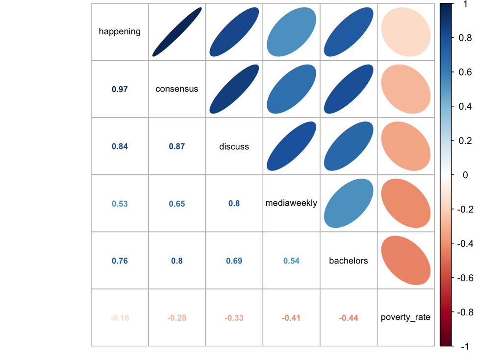

**c.**

**Table 1. Regression Results.** The table shows relationships between each variable, and the dependent variable, Percentage Global Warming Believers. Data used with permission from the Yale Program on Climate Change Communication (Yale Climate Opinion Maps 2018).

|  | Percentage Global Warming Believers |
| --- | --- |
| Weekly Media Exposure | 0.430*** (0.146) |
| Percentage Bachelor Degrees | 0.540*** (0.073) |
| Poverty Rate | 0.372*** (0.130) |
| State With Coastline: Yes | 3.544*** (0.707) |
| Constant | 35.600*** (4.254) |
| *N* | 51 |
| R<sup>2</sup> | 0.776 |
| Adjusted R<sup>2</sup> | 0.756 |
| Residual Std. Error | 2.455 (df = 46) |
| F Statistic | 39.818*** (df = 4; 46) |
| *Notes:* | ***Significant at the 1 percent level. |
|  | **Significant at the 5 percent level. |
|  | *Significant at the 10 percent level. |

**d.**

- The coefficient of “State With Coastline: Yes” explains that if every other variable in the model stayed constant, for states with a coastline, the proportion who believe in climate change is on average 3.54% more than states without a coastline.
- The coefficient of “Poverty Rate”" explains that if every other variable in the model stayed constant, a 1% increase in poverty rate increases the proportion of people who believe in climate change by 0.372%.

### Task 2

**UCSB Campus Climate Survey - Perceptions of Campus Respectfulness by Respondent Race/Ethnicity**

**a.** To determine if there is a significant association between the race/ethnicity and perception of campus respect, a chi-squared test was performed on the number of counts for each perception category.

**b.** Based on the data from a survey of UCSB responsdents regarding campus respect (Very Respectful, Respectful, Disrespectful, and Very Disrespectful) by ethnicity African American/African/Black (n=6791), American Indian/Alaskan Native (n=6095), Asian/Asian American (n=6942), Hispanic/Latino (n=6954), Middle Eastern/South Asian/North African (n=6621), Pacific Islander (n=6366), and White (n=7426); the campus climate opinions of survey respondents differed significantly by race (x<sup>2</sup>(18) = 1489.6, *p*<0.001, $\alpha$ = 0.05).

**c.**

Table 2. Counts and Proportions of Perceived Campus Respect according to Race/Ethnicity. Data used with permission from Ranklin & Associates Consulting (Ranklin & Associates, 2014).

| Race/Ethnicity | Perceived Campus Respect Counts and Proportions Very Respectful | Perceived Campus Respect Counts and Proportions Respectful | Perceived Campus Respect Counts and Proportions Disrespectful | Perceived Campus Respect Counts and Proportions Very Disrespectful |
| --- | --- | --- | --- | --- |
| African American/African/Black (n = 6791) | 1950 (0.287) | 4158 (0.612) | 562 (0.083) | 121 (0.018) |
| American Indian/Alaskan Native (n = 6095) | 1882 (0.309) | 3864 (0.634) | 271 (0.044) | 78 (0.013) |
| Asian/Asian American (n = 6942) | 2132 (0.307) | 4329 (0.624) | 424 (0.061) | 57 (0.008) |
| Hispanic/Latino (n = 6954) | 1979 (0.285) | 4324 (0.622) | 553 (0.08) | 98 (0.014) |
| Middle Eastern/South Asian/North African (n = 6621) | 1870 (0.282) | 4135 (0.625) | 507 (0.077) | 109 (0.016) |
| Pacific Islander (n = 6366) | 1959 (0.308) | 4126 (0.648) | 235 (0.037) | 46 (0.007) |
| White (n = 7426) | 3623 (0.488) | 3654 (0.492) | 108 (0.015) | 41 (0.006) |

**d.** Respondents identifying as White have a much higher rate of response for “Very Respectful” than any other Race/Ethnicity. Particularly, the proportion of respondents identifying as White who perceive the campus as being “Very Respectful” is nearly 20% more than those who identify as African American/African/Black. Overall, about 60% of respondents in each category other than “White” believe that the campus is “Respectful”.

### Task 3

**Effect of sex and age on self-consciousness (Taylor Manifest Anxiety Scale)**

**a.**

**Table 3: Logistic Regression Results.** Binomial logistic regression results show relationships between Sex and Age, and the dependent variable, Self-Consciousness. Data used with permission from Open Psychometrics (Taylor Manifest Anxiety Scale).

|  | Self-Consciousness |
| --- | --- |
| Sex - Male | -0.014 (0.080) |
| Age | -0.033*** (0.003) |
| Constant | 2.836*** (0.112) |
| *N* | 5,315 |
| Log Likelihood | -2,118.835 |
| Akaike Inf. Crit. | 4,243.671 |
| *Notes:* | ***Significant at the 1 percent level. |
|  | **Significant at the 5 percent level. |
|  | *Significant at the 10 percent level. |

**b.**

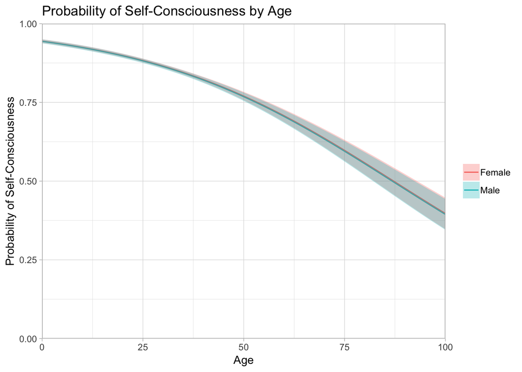

**c.** The above graph shows that male and females have close to the same probabilities of self-consciousness as age increases. Males are slightly less likely to be self-conscious than females overall, and as age increases, the probability of self-conciousness decreases, which aligns with the results found in Table 3.

### Task 4

**Pyraclostrobin residues on crops**

**a.** To determine the appropriate test, tests for normality were conducted. As shown in the graphs below, both the histograms and qqplots of each sample indicated non-normal distributions.

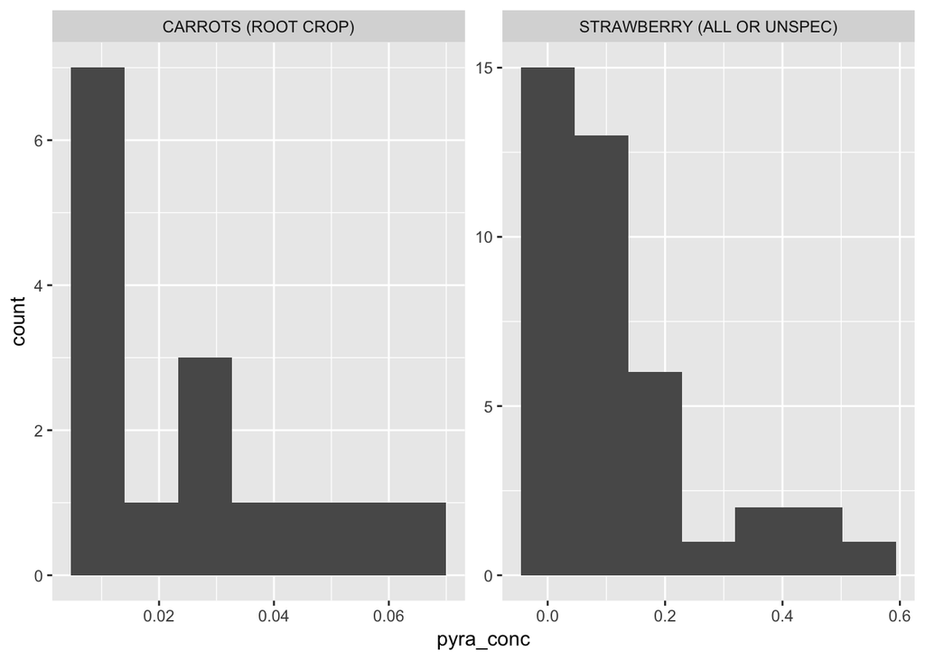

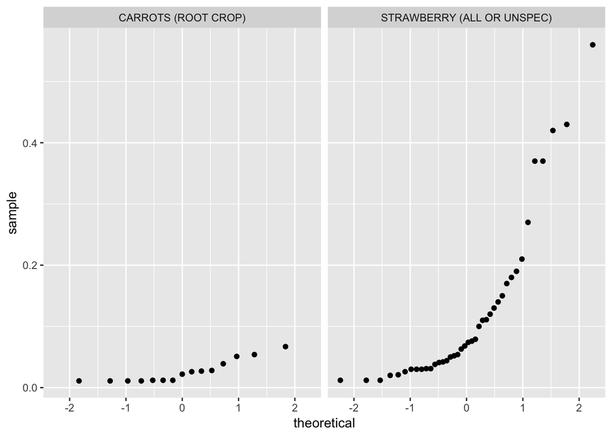

Both of the sample sizes are small. Strawberries have a sample size of 40, while Carrots have a sample size of 15. This makes it impossible to assume normality through the Central Limit Theorem. Due to the results of normality testing, it is concluded that the samples are non parametric. A Mann Whitney U test for ranks will be conducted.

**b.** Non-parametric Mann Whitney U Test for data collected from Carrots (n=15) and Strawberries (n=40) in California during 2014 revealed that the pyraclostrobin concentration (ppm) differs significantly between Carrots and Strawberries (W=91.5, *p*<0.0001). Also, a large effect size is observed (Cliff’s delta = 0.695), meaning that ranks of pyraclostrobin concentration (ppm) among Strawberries are mostly greater than ranks of pyraclostrobin concentration (ppm) among Carrots. Data used with permission from the California Department of Pesticide Regulation (California Department of Pesticide Regulation).

### Task 5

**Pesticides by County, California (2014)**

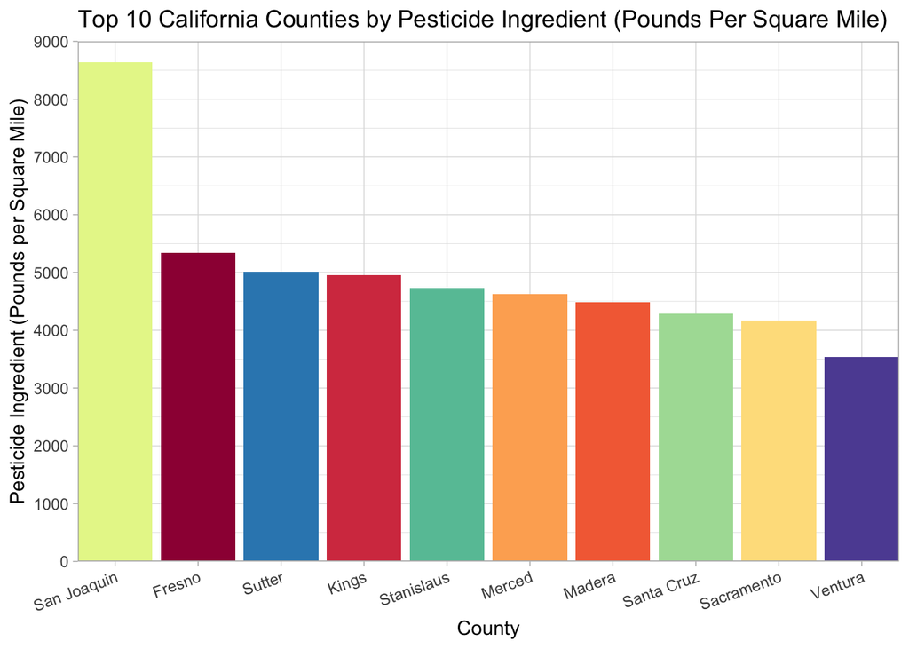

```r
per_sq_mile <- ca_pest %>%
  clean_names() %>%
  mutate(pounds_per_sq_mile = pounds_active_pesticide_ingredient_used/county_area_square_miles) %>%
  top_n(10, pounds_per_sq_mile) # get top ten values of pounds per sq mile

pest_col <- ggplot(aes(x = reorder(county, -pounds_per_sq_mile) , y = pounds_per_sq_mile), data = per_sq_mile) +
  geom_col(aes(fill = county), show.legend = FALSE) +
  theme_light() +
  theme(axis.text.x = element_text(angle = 20, hjust = 1)) +
  scale_x_discrete(expand = c(0,0)) +
  scale_y_continuous(expand = c(0,0), limits = c(0,9000), breaks = seq(0,9000, by = 1000)) +
  labs(x = "County", y = "Pesticide Ingredient (Pounds per Square Mile)", title = "Top 10 California Counties by Pesticide Ingredient (Pounds Per Square Mile)") +
  scale_fill_brewer(palette = "Spectral")

pest_col
```

### References

- California Department of Pesticide Regulation. (2014). Pesticide Residue Monitoring Program. Retrieved from https://www.cdpr.ca.gov/docs/enforce/residue/rsmonmnu.htm
- California Department of Pesticide Regulation. (2014). Pounds of Active Ingredient by County. Retrieved from https://www.cdpr.ca.gov/docs/pur/pur14rep/14_pur.htm
- Marlon, J., Howe, P., Mildenberger, M., Leiserowitz, A., & Wang, X. (2018). Yale Climate Opinion Maps 2018. Retrieved from http://climatecommunication.yale.edu/visualizations-data/ycom-us-2018/?est=happening&type=value&geo=county
- Ranklin & Associates, Consulting (2014, March). UCSB Campus Climate Project Final Report. Retrieved from http://diversity.ucsb.edu/CampusClimate/
- Taylor Manifest Anxiety Scale. (n.d.). Retrieved from https://openpsychometrics.org/tests/TMAS/